# Lecture 17 — Neural Networks and Training

Lecture 17

Kaveh Fathian

Computer Science Department, Colorado School of Mines

# Neural Networks

## Hand-Engineered vs. Learned Features

- **Classical detection:** features are designed by hand (HOG, Haar); only the classifier is learned.
- **Neural networks** learn the features and the classifier together, from data.

[figure not shown]

## The Perceptron

- A **neuron**: a weighted sum of the inputs plus a bias, followed by an **activation function** $\varphi$:

$$\bbox[border: 2px solid #c53030; padding: 2px 6px]{y = \varphi(\mathbf{w} \cdot \mathbf{x} + b)}\;\;{\color{#c53030}{\textbf{neuron}}}$$

- $\mathbf{w}$: weights; $b$: bias. Both are learned.
- **Perceptron:** a neuron with a step activation. It is a linear classifier: the boundary is the line $\mathbf{w} \cdot \mathbf{x} + b = 0$.

[figure not shown]

## Example: Perceptron Classification

- Perceptron is a linear classifier that can separate two classes.
- Trained weights and bias:

$$w_1 = 1.9,\quad w_2 = 2.4,\quad b = -0.9$$

$$y = \text{step}(1.9\,x_1 +2.4\,x_2 -0.9)$$

- The line $z = 0$ is the decision boundary that splits the plane into the two classes.

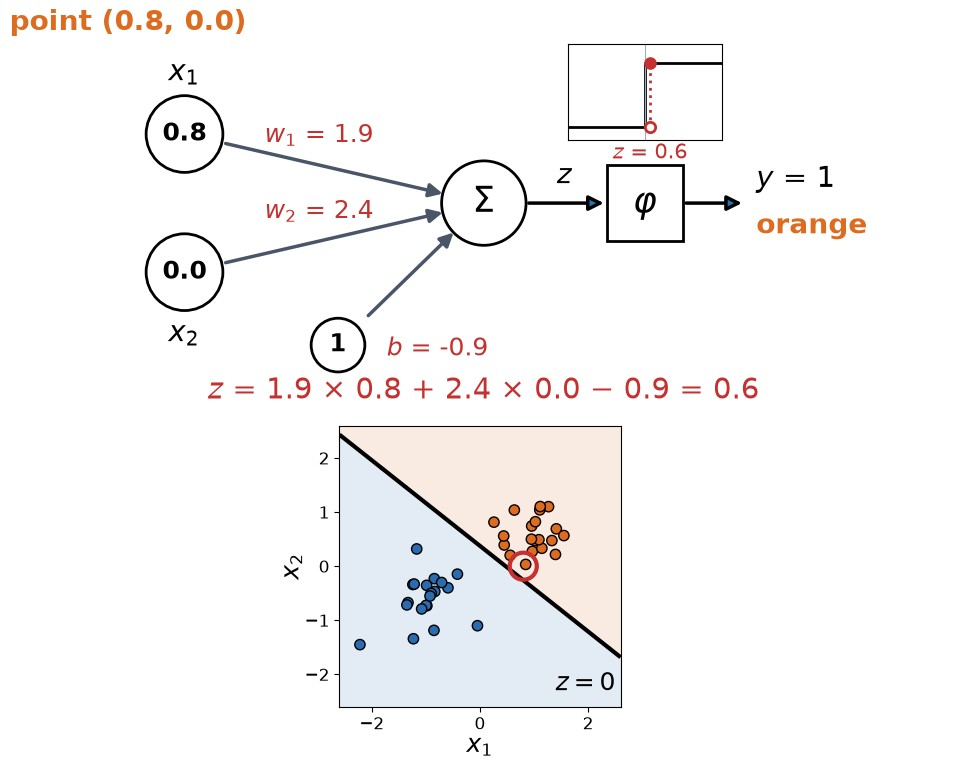

## Perceptron vs. SVM

- Same model: a line $\mathbf{w} \cdot \mathbf{x} + b = 0$.
- Different goal:
  - **SVM:** the line with the largest margin.
  - **Perceptron:** any line that separates the training points. Which one depends on the starting weights.

[figure not shown]

## Activation Functions

- **Activation** $\varphi$: turns the weighted sum $z$ into the neuron’s output.
- Without one, $\varphi(z) = z$: the output is linear, and combining linear neurons stays linear.
- **Step:** 0 or 1.
- **Sigmoid:** smooth, from 0 to 1. Saturate: flat for large $|z|$.
- **Tanh:** similar to sigmoid, but from −1 to 1. Saturate: flat for large $|z|$.
- **ReLU** $= \max(0, z)$: 0 for $z < 0$, $z$ otherwise. The default in neural networks.
  - The most common activation; smooth variants (e.g., GELU) are used in modern networks.

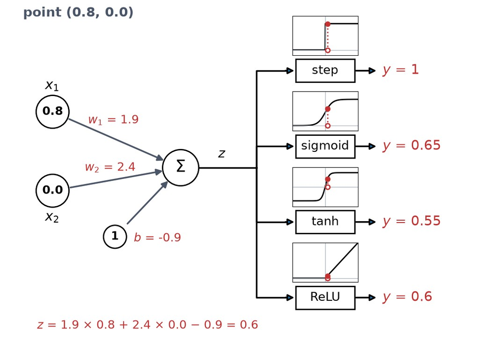

## A Compact Neuron Diagram

- To draw networks, combine the weighted sum and the activation into one circle: $\Sigma \,|\, \varphi$.
- The bias is still there, but it is not drawn as an edge. It is written next to the neuron or left out.
- In a network diagram, each circle is one neuron and each edge is one weight.

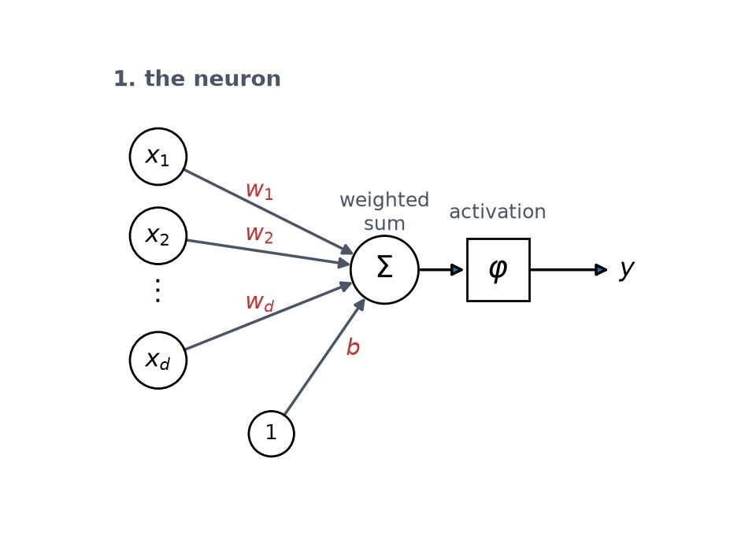

## Multi-Layer Perceptron (MLP)

- Neurons in **layers**: an input layer, one or more hidden layers, an output layer.
- **Input layer:** just the input numbers.
- Each edge has a weight; each neuron after the input layer has a bias and an activation.
- **Hidden layers:** weighted sum, bias and activation.
- **Output layer:** weighted sum and bias, usually no activation.
- **Fully connected layer:** every neuron is connected to every neuron of the previous layer.
- **Parameters:** all the weights and biases. This network: 46.

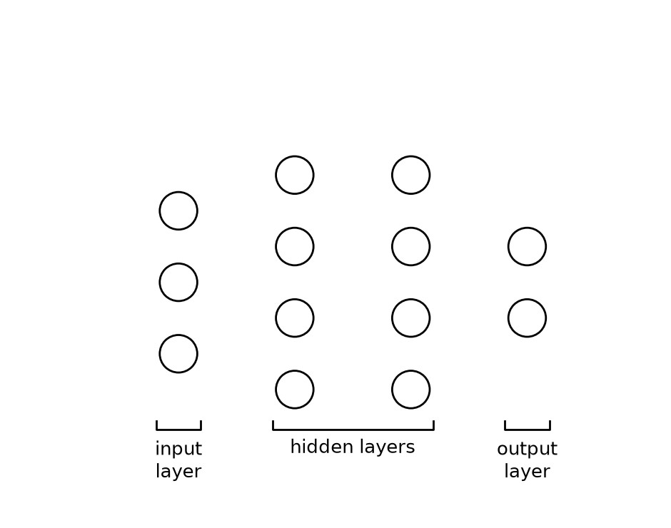

## MLP Example

Enter a point: *x*<sub>1</sub> *x*<sub>2</sub> or click on the plot

[interactive chart not shown]

*x*<sub>1</sub> (right) and *x*<sub>2</sub> (up), from −2.2 to 2.2

## Output Layer: Softmax

- The output layer has one neuron per class. Its outputs, the $z_i$, can be any real numbers.
- **Softmax** turns them into probabilities that sum to 1:

$$\bbox[border: 2px solid #c53030; padding: 2px 6px]{p_i = \frac{e^{z_i}}{\sum_j e^{z_j}}}\;\;{\color{#c53030}{\textbf{softmax}}}$$

- The prediction is the class with the largest probability.

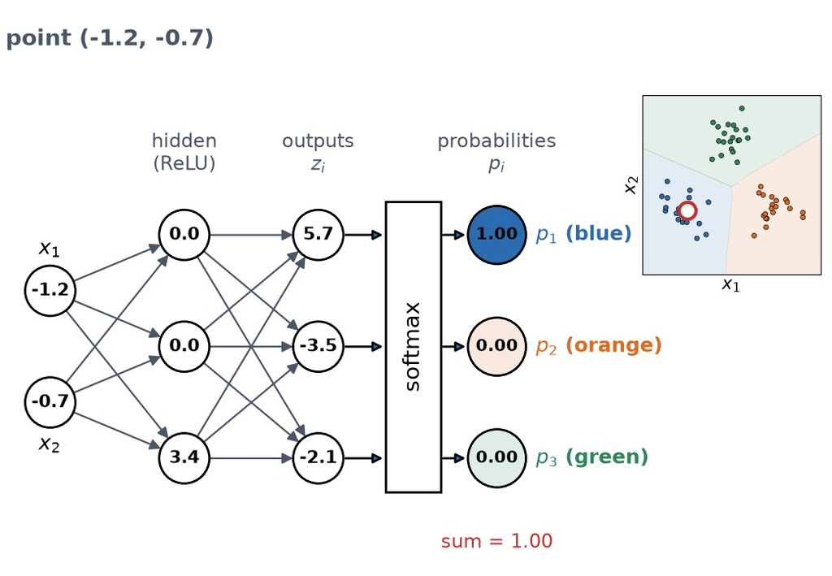

## Loss Functions & Training

- **Loss** $L$: *one number* that measures how far the predictions are from the labels.
- **Regression:** squared error of the NN output $y$ and target $y_{t}$: $\;\displaystyle L = (y - y_{t})^2$
- **Classification:** *cross-entropy*, with $p_{y_t}$ the softmax probability for the target/correct class: $\;\displaystyle L = -\log p_{y_t}$
- **Training:** finding the NN weights and biases $\theta$ that minimize the loss over all training points ($L_n$: loss of point $n$):

$$\bbox[border: 2px solid #c53030; padding: 2px 6px]{\min_\theta \; \sum_{n}{L_n}\;\;{\color{#c53030}{\textbf{training minimizes loss}}} }$$

[figure not shown]

## Example: Weights Change the Loss

- Two training points: **A** (blue) and **B** (orange).
- Change one weight $w$ of the small MLP and keep others fixed.
- Loss:

$$\begin{aligned}
L &= L_A + L_B \\
L_A &= -\log p_{\text{blue}}(A) \\
L_B &= -\log p_{\text{orange}}(B)
\end{aligned}$$

- Training searches for the weights with the lowest loss.

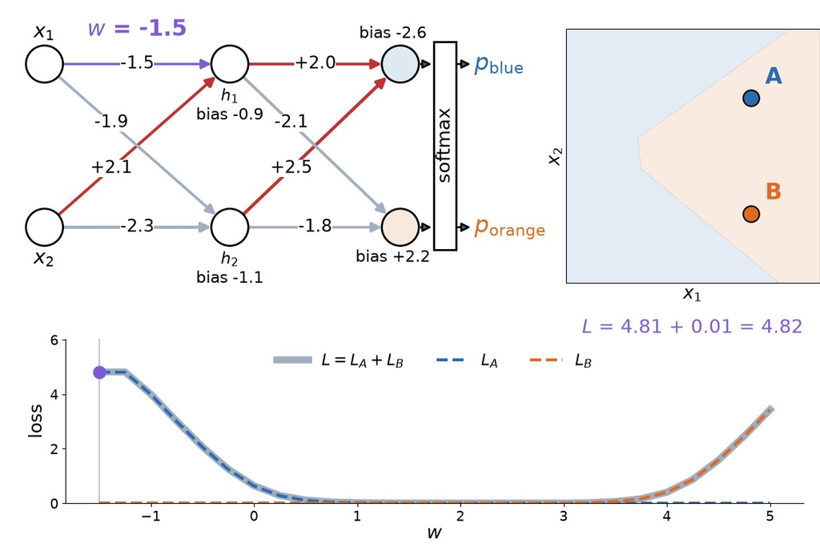

## Minimizing Loss: Gradient Descent

- **Gradient** $\nabla_\theta L$: the direction in which the loss increases fastest. $\theta$: all weights and biases.
- Step against it:

$$\bbox[border: 2px solid #c53030; padding: 2px 6px]{\theta \leftarrow \theta - \eta\, \nabla_\theta L}\;\;{\color{#c53030}{\begin{array}{l}\textbf{gradient}\\ \textbf{descent}\end{array}}}$$

- $\eta$: the **learning rate** (step size).
- The end point depends on the start: it can be a **local minimum**, not the lowest one.

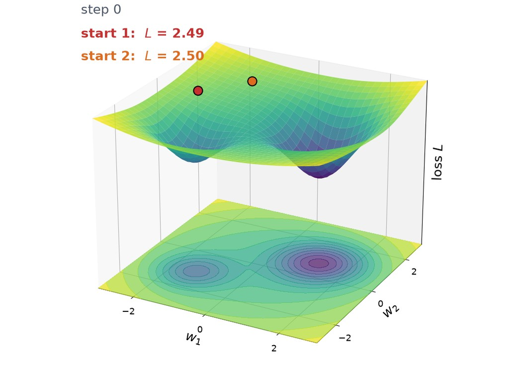

## Learning Rate

- The **learning rate** $\eta$ sets the step size. Too small is slow; too large overshoots or diverges.

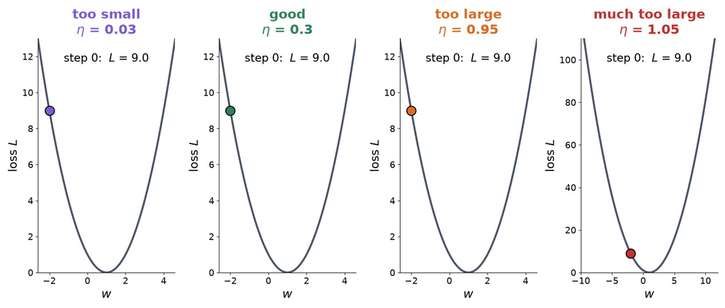

## Example: Training the MLP

- Start from random weights, then repeat gradient descent steps ($\eta$ = 0.5) on all 100 points, changing all 12 weights and biases at once.
- The weights change, the orange band forms, and the loss drops.

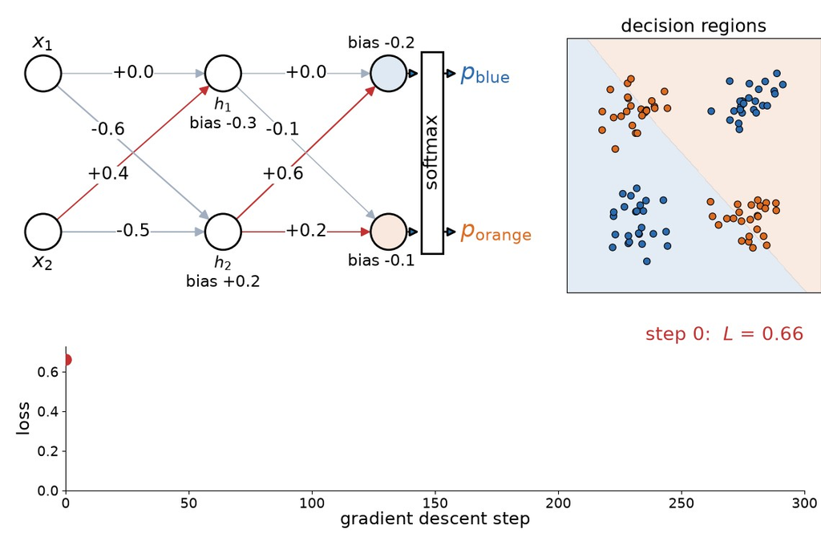

## Backpropagation (Supplementary)

- A network is a chain of functions. The **chain rule** gives each gradient as a product of local derivatives.
- **Backward pass:** start at the loss and go back layer by layer, reusing the products already computed.
- Cost: about one forward pass.

$$\bbox[border: 2px solid #c53030; padding: 2px 6px]{\frac{\partial L}{\partial w} = \frac{\partial L}{\partial h_1}\, \frac{\partial h_1}{\partial z_1}\, \frac{\partial z_1}{\partial w}}$$

$$= (-0.38)\,(1)\,(1.0) = -0.38$$

[figure not shown]

## Computing Gradients

- **Numerical:** nudge one weight and measure the change in loss. Simple, but approximate, and it needs one pass per weight.
- **Symbolic:** derive a formula. It becomes huge for deep networks.
- **Automatic differentiation (autodiff):** record the forward pass, then apply the chain rule backward. Exact, and about as fast as a forward pass.
- **Cost per step:** numerical needs 2 loss evaluations per weight; autodiff needs one forward and one backward pass.
- In PyTorch, `loss.backward()` uses **reverse-mode autodiff** (backpropagation), the standard way to train.

[figure not shown]

## Stochastic Gradient Descent (SGD)

- Computing the gradient over all training images at every step can be very slow (e.g., ~0.3 s for the 50,000 FashionMNIST images, vs. under 1 ms for a mini-batch of 64).
- **Stochastic gradient descent (SGD):** use a random **mini-batch** (e.g., 64 images) for each step. Noisy convergence, but cheap.
- **Epoch:** one pass through the entire training set.

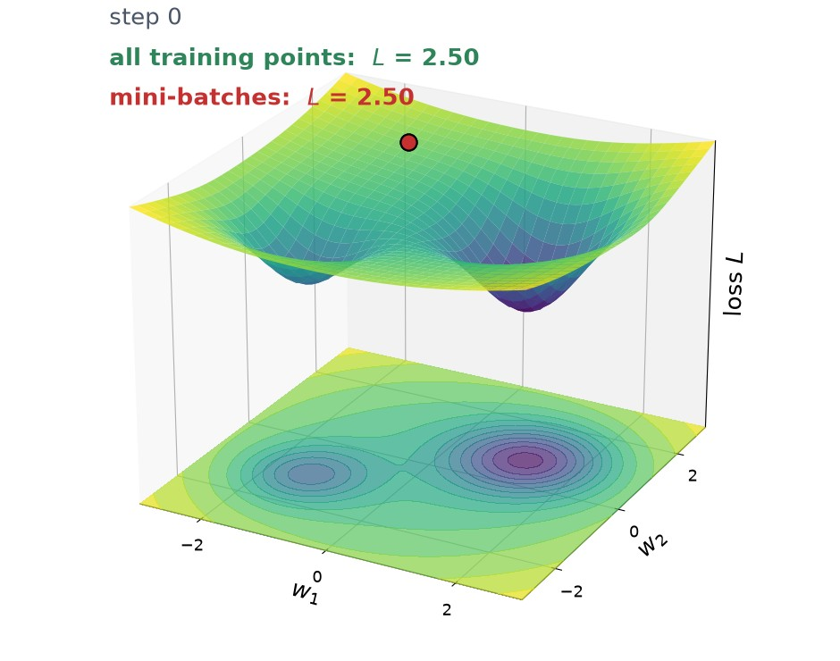

## Momentum and Adam

- SGD convergence can be improved with **momentum** or **Adam**.
- **Momentum:** averages recent steps. It smooths the noise and speeds up consistent directions.
- **Adam:** momentum plus a separate step size for each weight. A robust default.

[figure not shown]

## FashionMNIST Classification with an MLP

- **Task:** classify FashionMNIST images into 10 classes with an MLP: 784 pixels → 256 → 128 → 10 outputs.

[figure not shown]

## FashionMNIST MLP Classification in Code

- `nn.Sequential`: the layers, in order. `nn.Linear(784, 256)` is a fully connected layer.
- `nn.CrossEntropyLoss`: softmax and cross-entropy, applied to the outputs $z_i$.
- Each step:
  1. Forward pass and loss.
  2. `zero_grad`: clear the previous step’s gradients.
  3. `backward`: compute the new gradients.
  4. `step`: update the weights.
- **Self-study:** the PyTorch Basics tutorial.

```python
model = nn.Sequential(nn.Flatten(),           # 28 x 28 -> 784
                      nn.Linear(784, 256), nn.ReLU(),
                      nn.Linear(256, 128), nn.ReLU(),
                      nn.Linear(128, 10))     # 10 outputs
loss_fn = nn.CrossEntropyLoss()
optimizer = torch.optim.Adam(model.parameters(), lr=1e-3)

for epoch in range(10):
    for images, labels in train_loader:       # batches of 64
        loss = loss_fn(model(images), labels)
        optimizer.zero_grad()
        loss.backward()                       # autodiff
        optimizer.step()                      # update

with torch.no_grad():
    pred = model(X_test).argmax(1)
test_acc = (pred == y_test).float().mean()
```

## FashionMNIST MLP: Full Code

```python
import gzip
import time
from pathlib import Path

import numpy as np
import torch
from torch import nn
from torch.utils.data import DataLoader, TensorDataset

torch.manual_seed(0)
data_dir = Path("assets/datasets/fashion_mnist")

# 1. Data: the same 50,000 / 10,000 / 10,000 split as before. Pixels scaled to 0–1.
def read_idx(name, offset):
    with gzip.open(data_dir / name) as f:
        return np.frombuffer(f.read(), np.uint8, offset=offset)

def images(name):
    return torch.tensor(read_idx(name, 16).reshape(-1, 28, 28) / 255, dtype=torch.float32)

def labels(name):
    return torch.tensor(read_idx(name, 8), dtype=torch.long)

X, y = images("train-images-idx3-ubyte.gz"), labels("train-labels-idx1-ubyte.gz")
X_test, y_test = images("t10k-images-idx3-ubyte.gz"), labels("t10k-labels-idx1-ubyte.gz")
train_loader = DataLoader(TensorDataset(X[:50000], y[:50000]), batch_size=64, shuffle=True)
X_val, y_val = X[50000:], y[50000:]

# 2. The MLP: 784 pixels -> 256 -> 128 -> 10 outputs.
model = nn.Sequential(nn.Flatten(),
                      nn.Linear(784, 256), nn.ReLU(),
                      nn.Linear(256, 128), nn.ReLU(),
                      nn.Linear(128, 10))
loss_fn = nn.CrossEntropyLoss()                      # softmax + cross-entropy
optimizer = torch.optim.Adam(model.parameters(), lr=1e-3)

def accuracy(images, labels):
    with torch.no_grad():
        return (model(images).argmax(1) == labels).float().mean().item()

# 3. Training: mini-batch steps with Adam, 10 epochs.
t0 = time.perf_counter()
for epoch in range(10):
    for images, labels in train_loader:
        loss = loss_fn(model(images), labels)        # forward pass and loss
        optimizer.zero_grad()
        loss.backward()                              # gradients (autodiff)
        optimizer.step()                             # update the weights
    print(f"epoch {epoch + 1}: validation accuracy {100 * accuracy(X_val, y_val):.1f}%")
train_time = time.perf_counter() - t0

# 4. Test.
t0 = time.perf_counter()
test_acc = accuracy(X_test, y_test)
time_per_image = (time.perf_counter() - t0) / len(X_test)
n_params = sum(p.numel() for p in model.parameters())
print(f"test accuracy: {100 * test_acc:.1f}%")
print(f"training time: {train_time:.1f} s, time per image: {1e6 * time_per_image:.1f} µs")
print(f"parameters: {n_params:,}")
```

## Our FashionMNIST Benchmark

| Method | Input | Test accuracy | Training time | Time per image | Model size |
| --- | --- | --- | --- | --- | --- |
| KNN ($k$ = 6) | 784 pixels | 85.0% | none | 5.5 ms | 157 MB |
| KNN ($k$ = 6) | 50 PCA features | 85.6% | PCA only | 0.3 ms | 10 MB |
| SVM (RBF) | 50 PCA features | 88.8% | 15.4 s | 0.2 ms | 3.1 MB |
| **MLP** | 784 pixels | 88.2% | 16.6 s | < 0.1 ms | 0.9 MB |

These results come from a separate run on a different machine, so some results differ slightly from the earlier table.

- MLP: -0.6 points vs. the SVM, learning its own features from the pixels.
- Like KNN on pixels, the MLP is **sensitive to shifts**: a 2-pixel shift of the test images drops it to **55.0%**.

[figure not shown]